# Introduction

The National Football League, also known as the NFL, was established in 1920 and made in the United States. Althogh it was created more than 100 years ago, a lot of the modern stats that we have today weren't recored. Some of the more important stats that I'm looking at pertain to the Quarterback position in the NFL. I got the [NFL Statistics](https://www.kaggle.com/datasets/kendallgillies/nflstatistics/) dataset from Kaggle.com.This data was collected on NFL.com and put into a dataset. The dataset looks at specific game logs from the NFL and focuses on the QBs' stats in that game. Originally, this dataset included 40,247 games from the years 1970-2016. This dataset wasn't perfect for me to use as is, so I had to do a lot of data wrangling to make sure all of the data was in a specific form in order for me to run tests and answer my questions to my best ability. One of the major challenges that I faced was making sure all of the data was in a certain format that would allow me to run all of my models and find the answers to my questions. Converting the dataset from kaggle to jupyterhub is a challenge in itself because of the differences between the two. I had to do things like change the names of the columns, change the datatypes of the columns, and drop some of the values that weren't needed.

In these two notebooks, I will be exploring and answering some of the questions that I had initally when I was looking at the dataset. The questions include: Is there a significant correlation between the year and number of passes? Is there a significat correlation between Passer Rating and Week that the QB played? Can I predict the Passer Rating? Is the win column based on a QB’s qbr (can we predict the W/L column using the qbr)? All of these questions are related. They will allow me to understand how important quarterbacks are to their team.

Gillies, Kendall. “NFL Statistics.” Kaggle, 9 June 2017, www.kaggle.com/datasets/kendallgillies/nflstatistics/.

## Import Libraries And Import Dataset

```python
import pandas as pd
import numpy as np
import seaborn as sns
import matplotlib.pyplot as plt
sns.set_theme()

from sklearn.model_selection import train_test_split
from sklearn.metrics import mean_squared_error, r2_score
from sklearn.neighbors import KNeighborsRegressor, KNeighborsClassifier
from sklearn.preprocessing import StandardScaler
from sklearn.model_selection import train_test_split
```

```python
qb = pd.read_csv('Game_Logs_Quarterback.csv')
qb
```

|  | Player Id | Name | Position | Year | Season | Week | Game Date | Home or Away | Opponent | Outcome | ... | Ints | Sacks | Sacked Yards Lost | Passer Rating | Rushing Attempts | Rushing Yards | Yards Per Carry | Rushing TDs | Fumbles | Fumbles Lost |
| --- | --- | --- | --- | --- | --- | --- | --- | --- | --- | --- | --- | --- | --- | --- | --- | --- | --- | --- | --- | --- | --- |
| 0 | jaredzabransky/2495791 | Zabransky, Jared | NaN | 2007 | Preseason | 1 | 08/11 | Home | CHI | L | ... | -- | -- | -- | 0.0 | -- | -- | -- | -- | -- | -- |
| 1 | jaredzabransky/2495791 | Zabransky, Jared | NaN | 2007 | Preseason | 2 | 08/18 | Away | ARI | W | ... | 0 | 0 | 0 | 46.9 | -- | -- | -- | -- | -- | -- |
| 2 | jaredzabransky/2495791 | Zabransky, Jared | NaN | 2007 | Preseason | 3 | 08/25 | Home | DAL | W | ... | -- | -- | -- | 0.0 | -- | -- | -- | -- | -- | -- |
| 3 | jaredzabransky/2495791 | Zabransky, Jared | NaN | 2007 | Preseason | 4 | 08/30 | Away | TB | L | ... | 1 | 2 | 13 | 50.8 | 2 | 17 | 8.5 | 0 | -- | -- |
| 4 | billdemory/2512778 | Demory, Bill | NaN | 1974 | Regular Season | 1 | 09/15 | Away | KC | L | ... | -- | -- | -- | 0.0 | -- | -- | -- | -- | -- | -- |
| ... | ... | ... | ... | ... | ... | ... | ... | ... | ... | ... | ... | ... | ... | ... | ... | ... | ... | ... | ... | ... | ... |
| 40242 | steveramsey/2523725 | Ramsey, Steve | NaN | 1971 | Regular Season | 12 | 12/05 | Home | CHI | W | ... | 2 | 3 | 27 | 25.3 | 2 | 0 | 0.0 | 0 | -- | -- |
| 40243 | steveramsey/2523725 | Ramsey, Steve | NaN | 1971 | Regular Season | 13 | 12/12 | Away | SD | L | ... | 3 | 1 | 6 | 37.3 | -- | -- | -- | -- | -- | -- |
| 40244 | steveramsey/2523725 | Ramsey, Steve | NaN | 1971 | Regular Season | 14 | 12/19 | Away | OAK | L | ... | 1 | 2 | 13 | 57.5 | 1 | 6 | 6.0 | 0 | -- | -- |
| 40245 | steveramsey/2523725 | Ramsey, Steve | NaN | 1970 | Regular Season | 13 | 12/13 | Home | SF | L | ... | -- | -- | -- | 0.0 | -- | -- | -- | -- | -- | -- |
| 40246 | steveramsey/2523725 | Ramsey, Steve | NaN | 1970 | Regular Season | 14 | 12/20 | Home | CHI | L | ... | 0 | 0 | 0 | 39.6 | -- | -- | -- | -- | -- | -- |

40247 rows × 29 columns

This is the dataset that I will be working with. This data represents game logs for quarterbakcs in the NFL. Each row represents a Quarterback that played in a specific game. Each column represents informaiton about the quarterback or the game. It inclueds stats like passing yards and data about the game like whether the QBs team lost or won the game. Using this dataset I will be able to answer the questions that were stated above.

## Data Wrangling and Exploratory Data Analysis

```python
qb = qb.drop(columns='Position')
qb
```

|  | Player Id | Name | Year | Season | Week | Game Date | Home or Away | Opponent | Outcome | Score | ... | Ints | Sacks | Sacked Yards Lost | Passer Rating | Rushing Attempts | Rushing Yards | Yards Per Carry | Rushing TDs | Fumbles | Fumbles Lost |
| --- | --- | --- | --- | --- | --- | --- | --- | --- | --- | --- | --- | --- | --- | --- | --- | --- | --- | --- | --- | --- | --- |
| 0 | jaredzabransky/2495791 | Zabransky, Jared | 2007 | Preseason | 1 | 08/11 | Home | CHI | L | 19 to 20 | ... | -- | -- | -- | 0.0 | -- | -- | -- | -- | -- | -- |
| 1 | jaredzabransky/2495791 | Zabransky, Jared | 2007 | Preseason | 2 | 08/18 | Away | ARI | W | 33 to 20 | ... | 0 | 0 | 0 | 46.9 | -- | -- | -- | -- | -- | -- |
| 2 | jaredzabransky/2495791 | Zabransky, Jared | 2007 | Preseason | 3 | 08/25 | Home | DAL | W | 28 to 16 | ... | -- | -- | -- | 0.0 | -- | -- | -- | -- | -- | -- |
| 3 | jaredzabransky/2495791 | Zabransky, Jared | 2007 | Preseason | 4 | 08/30 | Away | TB | L | 24 to 31 | ... | 1 | 2 | 13 | 50.8 | 2 | 17 | 8.5 | 0 | -- | -- |
| 4 | billdemory/2512778 | Demory, Bill | 1974 | Regular Season | 1 | 09/15 | Away | KC | L | 16 to 24 | ... | -- | -- | -- | 0.0 | -- | -- | -- | -- | -- | -- |
| ... | ... | ... | ... | ... | ... | ... | ... | ... | ... | ... | ... | ... | ... | ... | ... | ... | ... | ... | ... | ... | ... |
| 40242 | steveramsey/2523725 | Ramsey, Steve | 1971 | Regular Season | 12 | 12/05 | Home | CHI | W | 6 to 3 | ... | 2 | 3 | 27 | 25.3 | 2 | 0 | 0.0 | 0 | -- | -- |
| 40243 | steveramsey/2523725 | Ramsey, Steve | 1971 | Regular Season | 13 | 12/12 | Away | SD | L | 17 to 45 | ... | 3 | 1 | 6 | 37.3 | -- | -- | -- | -- | -- | -- |
| 40244 | steveramsey/2523725 | Ramsey, Steve | 1971 | Regular Season | 14 | 12/19 | Away | OAK | L | 13 to 21 | ... | 1 | 2 | 13 | 57.5 | 1 | 6 | 6.0 | 0 | -- | -- |
| 40245 | steveramsey/2523725 | Ramsey, Steve | 1970 | Regular Season | 13 | 12/13 | Home | SF | L | 27 to 38 | ... | -- | -- | -- | 0.0 | -- | -- | -- | -- | -- | -- |
| 40246 | steveramsey/2523725 | Ramsey, Steve | 1970 | Regular Season | 14 | 12/20 | Home | CHI | L | 3 to 24 | ... | 0 | 0 | 0 | 39.6 | -- | -- | -- | -- | -- | -- |

40247 rows × 28 columns

Here we are getting rid of the postition column in the datset. We are doing this because all of the information is about quarterbacks, so we don't need to focus on the position. This will allow us to have more concise data and make sure our output is as accurate as possible.

```python
qb.info()
```

```
<class 'pandas.core.frame.DataFrame'>
RangeIndex: 40247 entries, 0 to 40246
Data columns (total 28 columns):
 #   Column                     Non-Null Count  Dtype
---  ------                     --------------  -----
 0   Player Id                  40247 non-null  object
 1   Name                       40247 non-null  object
 2   Year                       40247 non-null  int64
 3   Season                     40247 non-null  object
 4   Week                       40247 non-null  int64
 5   Game Date                  40247 non-null  object
 6   Home or Away               40247 non-null  object
 7   Opponent                   40247 non-null  object
 8   Outcome                    40247 non-null  object
 9   Score                      40247 non-null  object
```

[output cut: 20 more lines]

Here I am looking at all of the names of the columns to make sure they are formated similarly. If they are formatted similarly, this will make a lot of the code easier to come up with and make sure mistakes are avoidable as possible. I decided to rename some of the columns, so they are in a better format for the code that I write. For example, where there are spaces in the columns, I change it, so there is just an underscore instead of the space. This is more of an optional change, but I think it is useful in this context.

```python
qb = qb.rename(columns={'Passing Yards': 'Passing_Yards'})
qb = qb.rename(columns={'Passes Completed': 'Passes_Completed'})
qb = qb.rename(columns={'TD Passes': 'TD_Passes'})
qb = qb.rename(columns={'Rushing Attempts': 'Rushing_Attempts'})
qb = qb.rename(columns={'Sacked Yards Lost': 'Sacked_Yards_Lost'})
qb = qb.rename(columns={'Games Started': 'Games_Started'})
qb = qb.rename(columns={'Completion Percentage': 'Completion_Percentage'})
qb = qb.rename(columns={'Passing Yards Per Attempt': 'Passing_Yards_Per_Attempt'})
qb = qb.rename(columns={'Rushing Yards': 'Rushing_Yards'})
qb = qb.rename(columns={'Rushing TDs': 'Rushing_TDs'})
qb = qb.rename(columns={'Fumbles Lost': 'Fumbles_Lost'})
qb = qb.rename(columns={'Game Date': 'Game_Date'})
qb = qb.rename(columns={'Passes Attempted': 'Passes_Attempted'})
```

```python
qb = qb.dropna()
qb
```

|  | Player Id | Name | Year | Season | Week | Game_Date | Home or Away | Opponent | Outcome | Score | ... | Ints | Sacks | Sacked_Yards_Lost | Passer Rating | Rushing_Attempts | Rushing_Yards | Yards Per Carry | Rushing_TDs | Fumbles | Fumbles_Lost |
| --- | --- | --- | --- | --- | --- | --- | --- | --- | --- | --- | --- | --- | --- | --- | --- | --- | --- | --- | --- | --- | --- |
| 0 | jaredzabransky/2495791 | Zabransky, Jared | 2007 | Preseason | 1 | 08/11 | Home | CHI | L | 19 to 20 | ... | -- | -- | -- | 0.0 | -- | -- | -- | -- | -- | -- |
| 1 | jaredzabransky/2495791 | Zabransky, Jared | 2007 | Preseason | 2 | 08/18 | Away | ARI | W | 33 to 20 | ... | 0 | 0 | 0 | 46.9 | -- | -- | -- | -- | -- | -- |
| 2 | jaredzabransky/2495791 | Zabransky, Jared | 2007 | Preseason | 3 | 08/25 | Home | DAL | W | 28 to 16 | ... | -- | -- | -- | 0.0 | -- | -- | -- | -- | -- | -- |
| 3 | jaredzabransky/2495791 | Zabransky, Jared | 2007 | Preseason | 4 | 08/30 | Away | TB | L | 24 to 31 | ... | 1 | 2 | 13 | 50.8 | 2 | 17 | 8.5 | 0 | -- | -- |
| 4 | billdemory/2512778 | Demory, Bill | 1974 | Regular Season | 1 | 09/15 | Away | KC | L | 16 to 24 | ... | -- | -- | -- | 0.0 | -- | -- | -- | -- | -- | -- |
| ... | ... | ... | ... | ... | ... | ... | ... | ... | ... | ... | ... | ... | ... | ... | ... | ... | ... | ... | ... | ... | ... |
| 40242 | steveramsey/2523725 | Ramsey, Steve | 1971 | Regular Season | 12 | 12/05 | Home | CHI | W | 6 to 3 | ... | 2 | 3 | 27 | 25.3 | 2 | 0 | 0.0 | 0 | -- | -- |
| 40243 | steveramsey/2523725 | Ramsey, Steve | 1971 | Regular Season | 13 | 12/12 | Away | SD | L | 17 to 45 | ... | 3 | 1 | 6 | 37.3 | -- | -- | -- | -- | -- | -- |
| 40244 | steveramsey/2523725 | Ramsey, Steve | 1971 | Regular Season | 14 | 12/19 | Away | OAK | L | 13 to 21 | ... | 1 | 2 | 13 | 57.5 | 1 | 6 | 6.0 | 0 | -- | -- |
| 40245 | steveramsey/2523725 | Ramsey, Steve | 1970 | Regular Season | 13 | 12/13 | Home | SF | L | 27 to 38 | ... | -- | -- | -- | 0.0 | -- | -- | -- | -- | -- | -- |
| 40246 | steveramsey/2523725 | Ramsey, Steve | 1970 | Regular Season | 14 | 12/20 | Home | CHI | L | 3 to 24 | ... | 0 | 0 | 0 | 39.6 | -- | -- | -- | -- | -- | -- |

40247 rows × 28 columns

```python
qb= qb.replace(['--'], pd.NA)
```

```python
qb= qb.replace(['T'], pd.NA)
```

```python
qb = qb.dropna(how='any')
qb
```

|  | Player Id | Name | Year | Season | Week | Game_Date | Home or Away | Opponent | Outcome | Score | ... | Ints | Sacks | Sacked_Yards_Lost | Passer Rating | Rushing_Attempts | Rushing_Yards | Yards Per Carry | Rushing_TDs | Fumbles | Fumbles_Lost |
| --- | --- | --- | --- | --- | --- | --- | --- | --- | --- | --- | --- | --- | --- | --- | --- | --- | --- | --- | --- | --- | --- |
| 31 | tomsavage/2543640 | Savage, Tom | 2016 | Preseason | 2 | 08/20 | Home | NO | W | 16 to 9 | ... | 0 | 2 | 26 | 76.7 | 1 | 1 | 1.0 | 0 | 1 | 1 |
| 49 | tomsavage/2543640 | Savage, Tom | 2016 | Regular Season | 17 | 01/01 | Away | TEN | L | 17 to 24 | ... | 0 | 1 | 15 | 67.2 | 2 | 1 | 0.5 | 0 | 1 | 1 |
| 52 | tomsavage/2543640 | Savage, Tom | 2015 | Preseason | 1 | 08/15 | Home | SF | W | 23 to 10 | ... | 0 | 0 | 0 | 102.4 | 4 | 7 | 1.8 | 0 | 1 | 0 |
| 55 | tomsavage/2543640 | Savage, Tom | 2015 | Preseason | 4 | 09/03 | Away | DAL | L | 14 to 21 | ... | 1 | 3 | 6 | 81.8 | 2 | 9 | 4.5 | 0 | 1 | 1 |
| 73 | tomsavage/2543640 | Savage, Tom | 2014 | Regular Season | 15 | 12/14 | Away | IND | L | 10 to 17 | ... | 1 | 1 | 5 | 51.9 | 4 | -4 | -1.0 | 0 | 2 | 1 |
| ... | ... | ... | ... | ... | ... | ... | ... | ... | ... | ... | ... | ... | ... | ... | ... | ... | ... | ... | ... | ... | ... |
| 40115 | brockosweiler/2533436 | Osweiler, Brock | 2013 | Preseason | 2 | 08/17 | Away | SEA | L | 10 to 40 | ... | 1 | 4 | 22 | 45.5 | 2 | 12 | 6.0 | 0 | 1 | 1 |
| 40116 | brockosweiler/2533436 | Osweiler, Brock | 2013 | Preseason | 3 | 08/24 | Home | STL | W | 27 to 26 | ... | 1 | 1 | 10 | 49.0 | 1 | 0 | 0.0 | 0 | 1 | 1 |
| 40138 | brockosweiler/2533436 | Osweiler, Brock | 2012 | Preseason | 2 | 08/18 | Home | SEA | L | 10 to 30 | ... | 0 | 1 | 6 | 54.4 | 2 | 4 | 2.0 | 0 | 1 | 0 |
| 40159 | mattscott/2539647 | Scott, Matt | 2014 | Preseason | 2 | 08/16 | Home | NYJ | L | 17 to 25 | ... | 1 | 4 | 26 | 25.9 | 2 | 6 | 3.0 | 0 | 2 | 1 |
| 40164 | mattscott/2539647 | Scott, Matt | 2013 | Preseason | 4 | 08/29 | Away | ATL | W | 20 to 16 | ... | 1 | 1 | 8 | 32.3 | 2 | -3 | -1.5 | 0 | 1 | 1 |

3967 rows × 28 columns

Here I am getting rid of the rest of the null values by singling out specific rows and and droping them fully if they have any null values in any of the columns in that specific row. This narrows down my dataset, so I can focus on the specific questions that I am asking. Once again, this makes my dataset smaller, but it is worth it becuase without this step, some of my models will not run. |

```python
qb.info()
```

```
<class 'pandas.core.frame.DataFrame'>
Index: 3967 entries, 31 to 40164
Data columns (total 28 columns):
 #   Column                     Non-Null Count  Dtype
---  ------                     --------------  -----
 0   Player Id                  3967 non-null   object
 1   Name                       3967 non-null   object
 2   Year                       3967 non-null   int64
 3   Season                     3967 non-null   object
 4   Week                       3967 non-null   int64
 5   Game_Date                  3967 non-null   object
 6   Home or Away               3967 non-null   object
 7   Opponent                   3967 non-null   object
 8   Outcome                    3967 non-null   object
 9   Score                      3967 non-null   object
```

[output cut: 20 more lines]

```python
qb.Rushing_Attempts = qb.Rushing_Attempts.astype(float)
qb.Passing_Yards = qb.Passing_Yards.astype(float)
qb.TD_Passes = qb.TD_Passes.astype(float)
qb.Sacked_Yards_Lost = qb.Sacked_Yards_Lost.astype(float)
qb.Games_Started = qb.Games_Started.astype(float)
qb.Completion_Percentage = qb.Completion_Percentage.astype(float)
qb.Passing_Yards_Per_Attempt = qb.Passing_Yards_Per_Attempt.astype(float)
qb.Rushing_Yards = qb.Rushing_Yards.astype(float)
qb.Rushing_TDs = qb.Rushing_TDs.astype(float)
qb.Fumbles_Lost = qb.Fumbles_Lost.astype(float)
qb.Fumbles = qb.Fumbles.astype(float)
qb.Sacks = qb.Sacks.astype(float)
qb.Ints = qb.Ints.astype(float)
qb.Passes_Attempted = qb.Passes_Attempted.astype(float)
```

```python
qb.info()
```

```
<class 'pandas.core.frame.DataFrame'>
Index: 3967 entries, 31 to 40164
Data columns (total 28 columns):
 #   Column                     Non-Null Count  Dtype
---  ------                     --------------  -----
 0   Player Id                  3967 non-null   object
 1   Name                       3967 non-null   object
 2   Year                       3967 non-null   int64
 3   Season                     3967 non-null   object
 4   Week                       3967 non-null   int64
 5   Game_Date                  3967 non-null   object
 6   Home or Away               3967 non-null   object
 7   Opponent                   3967 non-null   object
 8   Outcome                    3967 non-null   object
 9   Score                      3967 non-null   object
```

[output cut: 20 more lines]

I'm making sure here that they have changed to floats and that all of the columns have the right datatype.

```python
qb.Rushing_Yards.mean()
```

```
11.261406604487018
```

This is the mean of the rushing yards of the quarterbacks throughout the years of my dataset. I wanted to calculate this in order to get an idea of how many rushing yards a QB usually gets. This will help me find out if this is a good predictor for some of my models and it willl allow me to compare certain QBs to this average to see if they rush a lot or not. ?

```python
qb['Passer Rating'].median()
```

```
80.4
```

This is the median Passer Rating for all of the quarterbacks in this adjusted dataset. I did this in order to see if I could use this column to answer some of my questions. I also did this in order to compare this number to some of the other QBs passer ratings. By comparing them, I would be able to see if certain QBs were good or not and if they were an above average, average, or below average passer.

#### Scatterplot

[figure not shown]

```python
sns.relplot(x = "Opponent", y = "Passer Rating", hue="Home or Away", data = qb,aspect=3.2).set(
    title="Comparing the Passer Rating to the Rushing TDs",
    xlabel="Passer Rating of QB",
    ylabel="Rushing Touchdowns")
```

This grpah shows some of the quarterbacks performances grouped based on their opponent. This graph also shows whether they were home or away. Here we could see how QBs as a whole performed against teams as a whole and if being home or away had an effect or not. In this graph is is pretty scattered, but It seems that there is no real difference between the opponent. This is likely due to the years being from 1991-2016, so there is more room for a team to be good or bad. Overall, there seems to be no significant change in overall performance based on the team they play or if the team is home or away.

#### Bar plot

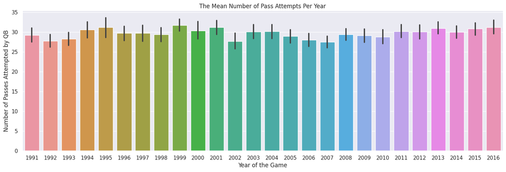

```python
sns.catplot(x="Year",y="Passes_Attempted",kind="bar",data=qb, aspect=3).set(
     xlabel="Year of the Game",
    ylabel='Number of Passes Attempted by QB',
    title='The Mean Number of Pass Attempts Per Year')
```

This graph shows the mean number of pass attempts grouped by the year. A lot of the means are very similar which means you can't base the pass attmepts on the year. The error bars are also very similar which means that there isn't a lot of room for variance. Overall, this grpah shows that there might be a low correlation between the number of passes the qb attempts and the year the games were played.

#### Box plot

[figure not shown]

```python
sns.catplot(x="Opponent",y="Rushing_Attempts",kind="box",data=qb, aspect=4).set(
    xlabel="Number of Rushing Attempts for the QB",
    ylabel='Opponent of the QB',
    title='The Rushing Attempts Grouped by the Opponent of the QB')
```

This grpah shows the median rushing attempts by a qb represented with the black line in the middle of each box. These boxes represent an interquartile range. Looking at this grpah, most of the inerquartile ranges are pretty similar. Teh outliers are all pretty similar too. This means that there isn't much of a difference to be seen when it comes to the opponent that the QB plays. They don't run more on one team and less against another.

#### Box Plot

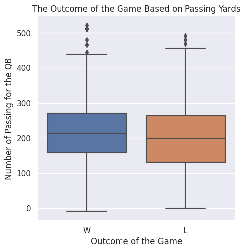

```python
sns.catplot(x="Outcome",y="Passing_Yards",kind="box",data=qb).set(
    xlabel="Outcome of the Game",
    ylabel='Number of Passing for the QB',
    title='The Outcome of the Game Based on Passing Yards')
```

This graph shows the difference between the median passing yards in outcomes that are wins and outcomes that are losses. Looking at this graph, there seems to not be a large difference between the two. The interquartile ranges are similar and the medians are similar too. The win outcome seems to have a little bit bigger of a 75th percentile and a little bit bigger median, but those differences aren't very vast. I think this give me a good idea when looking at my last question and at how it might be answered. This one stat doesn't seem to have a very big influence on a team winning or losing. This graph shows me that passing yards isn't as important when determining the outcome of the game.

### Correlation Hypothesis Test

## Question 1:

### Is there a significant correlation between the year and number of passes?

I wanted to ask this question because a lot of fans of the NFL say that running backs aren't as important as they used to be. In return, their claim is that as the years go on, the league has been passing a lot more then they used to be. I wanted to test this to see if there was a significant correlation between the year of the game and the the number of passes in said game. To do this I will be using the Year column and the Passes_Attempted column. This would give me an idea if they were passing more or not as the year go on. If the correlation is significant, then according to my dataset, it would prove that as the years go on, the NFL is passing the ball more. It is importnat to keep in mind that this would only answer the question for my specific dataset, and this doesn't mean that it is the same for the whole National Fooball League and its history. My dataset is only from 1991-2016. In addition, this would alow me to use this as a predictor in my other models if I needed to.

With this correlation test I will be comparing permutations to the observed correlation of my dataset. This will alow me to see if there is a significant difference using the p-value. With this being said, I will need to define my null hypothesis and my alternative hypothesis.

Null hypothesis: obs_corr = 0 Alternate hypothesis = obs_corr > 0

My null hypotheis is that my observed correlation is equal to zero. This would mean that there is no correlation between the number of passes and the year of the attempted passes. My alternative hypotheis is that the observed correlation is greater than 0. This would mean that there is a correlation between the year and number of passes. My hypothesis is one tailed, meaning that I am only testing in one direction. That direction being that the observed correlation is positive. I made it this way because as you can see below, the correlation between the two is postive, so I wanted to test in the positive direction.

```python
qb.corr(numeric_only=True)
```

|  | Year | Week | Games Played | Games_Started | Passes_Attempted | Completion_Percentage | Passing_Yards | Passing_Yards_Per_Attempt | TD_Passes | Ints | Sacks | Sacked_Yards_Lost | Passer Rating | Rushing_Attempts | Rushing_Yards | Rushing_TDs | Fumbles | Fumbles_Lost |
| --- | --- | --- | --- | --- | --- | --- | --- | --- | --- | --- | --- | --- | --- | --- | --- | --- | --- | --- |
| Year | 1.000000 | -0.131750 | -0.016282 | -0.061676 | 0.028627 | 0.124877 | 0.058712 | 0.055921 | 0.048273 | -0.101257 | -0.045991 | -0.045586 | 0.117389 | 0.055116 | 0.070182 | 0.056179 | -0.066213 | -0.002279 |
| Week | -0.131750 | 1.000000 | 0.014137 | 0.169956 | 0.158622 | -0.049754 | 0.125388 | -0.001908 | 0.088350 | 0.082696 | 0.045913 | 0.049318 | -0.021726 | 0.061900 | 0.050107 | 0.032741 | -0.007724 | -0.011556 |
| Games Played | -0.016282 | 0.014137 | 1.000000 | 0.041529 | 0.006632 | 0.004290 | 0.006160 | 0.000511 | -0.027967 | -0.002036 | -0.005176 | -0.015323 | -0.010722 | 0.007531 | -0.002669 | 0.004720 | 0.008357 | 0.013871 |
| Games_Started | -0.061676 | 0.169956 | 0.041529 | 1.000000 | 0.493387 | 0.114593 | 0.450873 | 0.114259 | 0.228168 | 0.156947 | 0.218809 | 0.195094 | 0.090776 | 0.154045 | 0.095862 | 0.053918 | 0.042614 | 0.069418 |
| Passes_Attempted | 0.028627 | 0.158622 | 0.006632 | 0.493387 | 1.000000 | 0.089718 | 0.813970 | 0.024241 | 0.349368 | 0.295509 | 0.226611 | 0.217131 | 0.046055 | 0.058411 | 0.071195 | 0.037036 | 0.074817 | 0.088251 |
| Completion_Percentage | 0.124877 | -0.049754 | 0.004290 | 0.114593 | 0.089718 | 1.000000 | 0.361884 | 0.553949 | 0.304421 | -0.180564 | -0.055647 | -0.066227 | 0.697596 | 0.033782 | -0.028714 | 0.052207 | -0.058111 | -0.013898 |
| Passing_Yards | 0.058712 | 0.125388 | 0.006160 | 0.450873 | 0.813970 | 0.361884 | 1.000000 | 0.514493 | 0.559863 | 0.134334 | 0.134627 | 0.125557 | 0.439362 | 0.091628 | 0.048161 | 0.066465 | 0.038129 | 0.070722 |
| Passing_Yards_Per_Attempt | 0.055921 | -0.001908 | 0.000511 | 0.114259 | 0.024241 | 0.553949 | 0.514493 | 1.000000 | 0.418416 | -0.147021 | -0.060780 | -0.066451 | 0.714253 | 0.077987 | 0.001148 | 0.061954 | -0.032303 | 0.000794 |
| TD_Passes | 0.048273 | 0.088350 | -0.027967 | 0.228168 | 0.349368 | 0.304421 | 0.559863 | 0.418416 | 1.000000 | -0.052448 | -0.045572 | -0.043008 | 0.642459 | 0.068069 | 0.036627 | -0.027884 | -0.023208 | 0.009441 |
| Ints | -0.101257 | 0.082696 | -0.002036 | 0.156947 | 0.295509 | -0.180564 | 0.134334 | -0.147021 | -0.052448 | 1.000000 | 0.110018 | 0.104933 | -0.555754 | -0.032470 | 0.021129 | -0.005935 | 0.051404 | 0.009851 |
| Sacks | -0.045991 | 0.045913 | -0.005176 | 0.218809 | 0.226611 | -0.055647 | 0.134627 | -0.060780 | -0.045572 | 0.110018 | 1.000000 | 0.877120 | -0.104267 | 0.065778 | 0.152446 | 0.010034 | 0.246796 | 0.204331 |
| Sacked_Yards_Lost | -0.045586 | 0.049318 | -0.015323 | 0.195094 | 0.217131 | -0.066227 | 0.125557 | -0.066451 | -0.043008 | 0.104933 | 0.877120 | 1.000000 | -0.110013 | 0.035910 | 0.117796 | 0.010062 | 0.233416 | 0.195045 |
| Passer Rating | 0.117389 | -0.021726 | -0.010722 | 0.090776 | 0.046055 | 0.697596 | 0.439362 | 0.714253 | 0.642459 | -0.555754 | -0.104267 | -0.110013 | 1.000000 | 0.079326 | -0.002286 | 0.029574 | -0.065064 | -0.013057 |
| Rushing_Attempts | 0.055116 | 0.061900 | 0.007531 | 0.154045 | 0.058411 | 0.033782 | 0.091628 | 0.077987 | 0.068069 | -0.032470 | 0.065778 | 0.035910 | 0.079326 | 1.000000 | 0.690334 | 0.281278 | 0.099739 | 0.003938 |
| Rushing_Yards | 0.070182 | 0.050107 | -0.002669 | 0.095862 | 0.071195 | -0.028714 | 0.048161 | 0.001148 | 0.036627 | 0.021129 | 0.152446 | 0.117796 | -0.002286 | 0.690334 | 1.000000 | 0.251607 | 0.042337 | 0.027947 |
| Rushing_TDs | 0.056179 | 0.032741 | 0.004720 | 0.053918 | 0.037036 | 0.052207 | 0.066465 | 0.061954 | -0.027884 | -0.005935 | 0.010034 | 0.010062 | 0.029574 | 0.281278 | 0.251607 | 1.000000 | 0.004443 | 0.005138 |
| Fumbles | -0.066213 | -0.007724 | 0.008357 | 0.042614 | 0.074817 | -0.058111 | 0.038129 | -0.032303 | -0.023208 | 0.051404 | 0.246796 | 0.233416 | -0.065064 | 0.099739 | 0.042337 | 0.004443 | 1.000000 | 0.383363 |
| Fumbles_Lost | -0.002279 | -0.011556 | 0.013871 | 0.069418 | 0.088251 | -0.013898 | 0.070722 | 0.000794 | 0.009441 | 0.009851 | 0.204331 | 0.195045 | -0.013057 | 0.003938 | 0.027947 | 0.005138 | 0.383363 | 1.000000 |

Here I am looking at the correaltion between all of the numerical values. With this I am seeing what has a correlation and what doesn't. This will help me with this model because I can look at if somehthing else correlates with passes attempted or the year. This will give me a better idea if maybe something else if a factor.

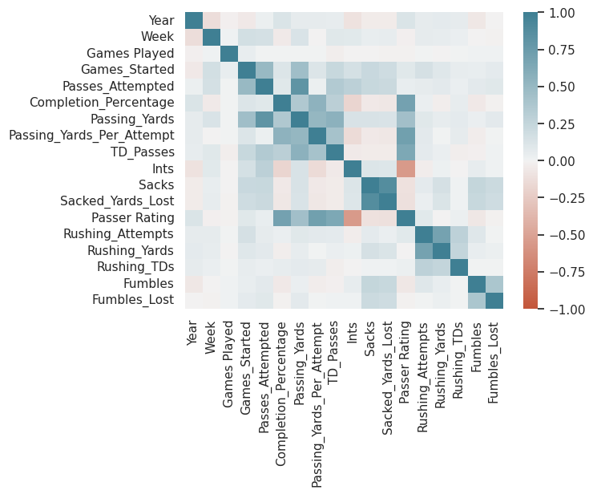

```python
(sns.heatmap(qb.corr(numeric_only=True),
             vmin=-1,
             vmax=1,
             cmap=sns.diverging_palette(20, 220, as_cmap=True)))
```

Here is a heatmap of the correlarions. This is just another way of looking at the correlations. You can identify the level or correlation by using the key off to the side of the graph. If the correaltion is dark blue, that means it has a high positive correlation. If the correlation is dark orange, that means it has a high negaive correlation. I thogutht that this was beneficial because it is an easier way at looking at all of the correlations.

#### Observed correlation

```python
obs_corr = qb.Year.corr(qb.Passes_Attempted)
obs_corr
```

```
0.028626839492466152
```

This is the observed correlation in the dataset. Here we are assigning the correlation between the year and the number of passes attmepted to a variable. This will allow us to use this in our following hypotheis test in order to answer our quesiton.

This corrleationn is pretty low, but it is postive. This is why I decided to use a one-tailed alternative hypothesis. Since the correlation is low, it is expected that it is not significant and likely due to chance instead of it being correlated for a reason. It is still important that we test it though to make sure it isn't a significant correlation.

#### Scatterplot with a Regression line

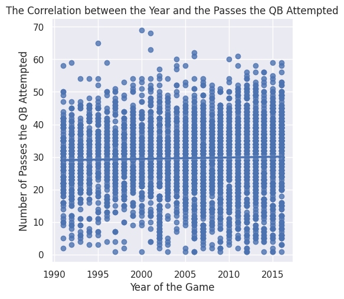

```python
sns.lmplot(x='Year',y='Passes_Attempted',data=qb).set(
    xlabel= 'Year of the Game',
    ylabel= 'Number of Passes the QB Attempted',
    title= 'The Correlation between the Year and the Passes the QB Attempted')
```

This grpah shows that there isn't much of a correlation between number of passes attempted and the year. The line of best fit is pretty horizontal and there doesn't seem to be much of a cluster of data that shows any type of trend. This means that I would start leaning towards the two not being correlated and it not having a significant correlation.

```python
def simulate_correlation(df,var1,var2):
    shuffled = df[var1].sample(frac=1).reset_index(drop=True)
    corr = shuffled.corr(df[var2])
    return corr
```

```python
corr_perms = ([simulate_correlation(qb,"Year","Passes_Attempted")
               for i in range(5000)])
corr_perms = pd.Series(corr_perms)
corr_perms
```

```
0      -0.087151
1      -0.025991
2      -0.012226
3      -0.112586
4      -0.026306
          ...
4995   -0.158376
4996   -0.065370
4997   -0.018864
4998    0.009651
4999   -0.053881
Length: 5000, dtype: float64
```

This ouptut are the permutations that we get from our model. We are going to use these permutations in order to compare them to our observed correlation to see if the observed correlation that we got it significat or not.

#### Histogram with observed correlation shown

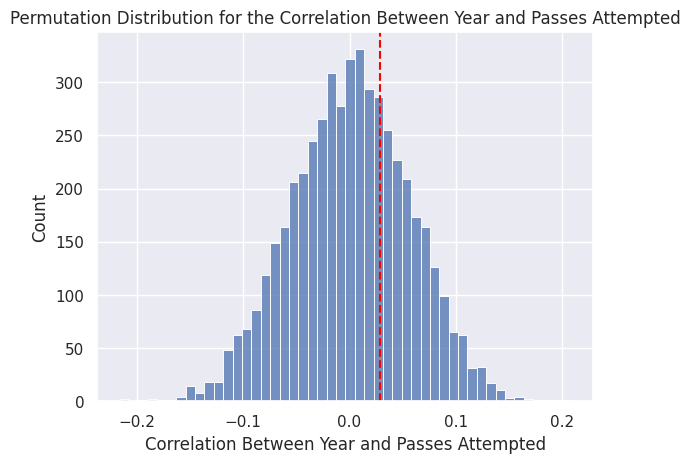

```python
plt = sns.histplot(x=corr_perms)
plt.set(
  title="Permutation Distribution for the Correlation Between Year and Passes Attempted",
  xlabel="Correlation Between Year and Passes Attempted")
plt.axvline(x=obs_corr, color="red", ls="--")
```

This histogram shows the permutations with the oberserved correaltion. All of the blue bars show the permutations of the grpah. The red dashed line is the observed correlation between passing attempts and the year of the attempts. The results show that there is not a significant correlation between year and the number of passing attempts. This is shown by the observed correlation. It is too close to zero and it seems that it can easily replicated with a simulation. There is too much permutation data to the right of the graph which means it is not far enough away from zero to be significant.

#### P-Value

```python
p_value = np.mean(corr_perms > obs_corr)
p_value
```

```
0.3156
```

This is our p-value. The p-value shows how much of the data is greater than the observed correlations.We want our p-value to be less than .05. Essentially, we want our p-value to be 5% and that means that we are 95% confident. The p-value shows how much of the data is greater than the observed correlations. Since our alternative hypothesis showed that we were looking for the observed correlaion to be more than zero, we look at all the permutations that are greater than the observed correlation. In this case our p_value was higher than what we were expecting. This means that we will accept our null hypothesis becuase the correlation is not significant enough for us to reject it.

Overall, this data shows us that the correlation between the Year column and the Passes_Attempted columnn is not signifcant. This answers our quesion and tells us that QB's are not passing more much more as the years go on.

## Question 2:

### Is there a significant correlation between Passer Rating and Week that the QB played?

#### (Does the QB get better, worse, or stay the same as the season goes on? And if so, is there a significant correlation?)

I wanted to ask this question becuase it would be interesting to see if quarterbacks get better as the weeks go on or if they regress as the season go on. It would make sense if the quarterbacks get better as the weeks go on because usually players learn from their mistakes and improve. I chose to look at the passer rating in particular because this is a good way of indicating how well a quarterback is doing. The passer rating takes into account some of the passing stats and puts it into an equation. The output of this equation ranges from 0-158.3, O being bad and 158.3 being perfect. I decided to use a correlation hypothesis test because the question is dealing with two specific variables that may or may not a have a correlation. In order to see if that correlation is significant or not, I will have to test it and this is the best way to do so.

With this correlation test I will be comparing permutations to the observed correlation between week and the passer rating of my dataset. This will allow me to see if there is a significant difference between the permutations and the observed correlation using the p-value. With this being said, I will need to define my null hypothesis and my alternative hypothesis.

Null hypothesis: obs_corr = 0 Alternate hypothesis = obs_corr < 0

#### Observed correlation

```python
obs_corr2 = qb['Week'].corr(qb['Passer Rating'])
obs_corr2
```

```
-0.021725631015044333
```

This is the observed correlation between the week of the game and the passer rating of the quarterback in that speicific game log. I am assigning this value to a variable, so I will be able to compare it to the permutations of my model at the end of this hypothesis test.

The correlation is again pretty low. It is negative which means they have a slightly inverse relationship, so as one goes up the other goes downn. We would want the coefficient to be around .7 or so for us to think that it is on the higher end of the correlation spectruem. Since it is so low we are more likely to think that the correlation is not significant, but we need to test it to make sure.

#### Scatterplot with a Regression line

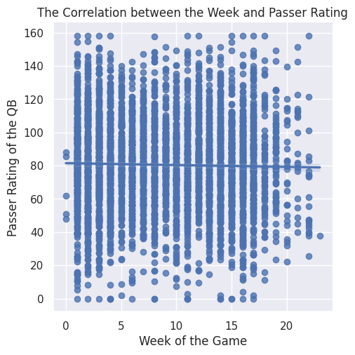

```python
sns.lmplot(x='Week',y='Passer Rating',data=qb).set(
    xlabel= 'Week of the Game',
    ylabel= 'Passer Rating of the QB',
    title= 'The Correlation between the Week and Passer Rating')
```

This grpah shows that there isn't much of a correlation between the week of the game in that particular season and the passer rating of the quarterback. The line of best fit is pretty horizontal, but slightly angled downward. There doesn't seem to be much of a cluster of data that shows any type of trend. This means that I would start leaning towards the two not being correlated and it not having a significant correlation.

```python
def simulate_correlation(df,var1,var2):
    shuffled = df[var1].sample(frac=1).reset_index(drop=True)
    corr2 = shuffled.corr(df[var2])
    return corr2
```

```python
corr_perms2 = ([simulate_correlation(qb,"Week","Passer Rating")
               for i in range(5000)])
corr_perms2 = pd.Series(corr_perms2)
corr_perms2
```

```
0       0.003758
1      -0.015279
2       0.022539
3      -0.016733
4      -0.008082
          ...
4995   -0.005260
4996   -0.075074
4997   -0.027740
4998   -0.091601
4999   -0.042889
Length: 5000, dtype: float64
```

These are some of the permutations that we made in order to compare them to the observed correlation. The permutations give you a set of correlations that are randomized and are strictly due to change. Using these, we are able to see if the observed correlation is due to chance or if it is due to there being a significant correlation.

#### Histogram

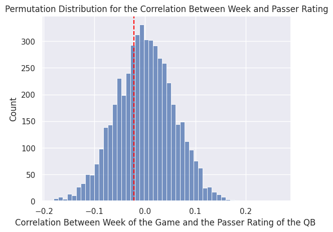

```python
plt = sns.histplot(x=corr_perms2)
plt.set(
  title="Permutation Distribution for the Correlation Between Week and Passer Rating",
  xlabel="Correlation Between Week of the Game and the Passer Rating of the QB ")
plt.axvline(x=obs_corr2, color="red", ls="--")
```

#### P-Value

```python
p_value = np.mean(corr_perms2 < obs_corr2)
p_value
```

```
0.3448
```

This is our p-value. We want our p-value to be less than .05. Essentially, we want our p-value to be 5% and that means that we are 95% confident. The p-value shows how much of the data is greater than the observed correlations. Since our alternative hypothesis showed that we were looking for the observed correlaion to be less than zero, we look at all the permutations that are less than the observed correlation. In this case our p_value was higher than what we wanted it to be. This means that we will accept our null hypothesis becuase the correlation is not significant enough for us to reject it.

## Question 3

### Can I predict the Passer Rating?

I wanted to see what goes into passer rating and what some of the important factors are in order to produce this stat. For this I knew that I needed to use a numerical model. I went through trial and error and found that Knn was the best model for this specific situation. This model would also help me find out what the good predictors would be for my next model too becuase passer rating is directly related to the QB's performance.

The target here is the passer rating of the QB. I decidced to use passing yards, compeltion percentage, touchdown passes, interceptions, passing yards per attempts, and sacks as my predictors. All of these are some of the main stats for a quarterback, so they proved to be good predictors for this particular model.

```python
target = "Passer Rating" # Our target variable
predictors = ["Passing_Yards", "Completion_Percentage", "TD_Passes", "Ints","Passing_Yards_Per_Attempt", "Sacks"] # A list of predictors
```

#### Scatter plot with regression line

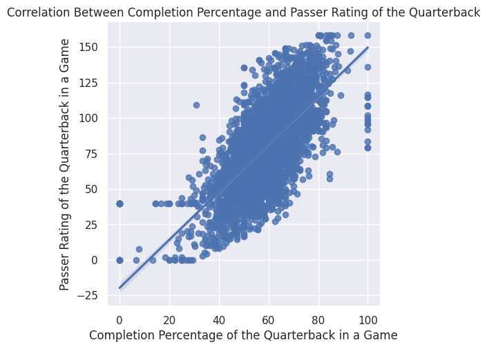

```python
sns.lmplot(x='Completion_Percentage',y='Passer Rating',data=qb).set(
      xlabel="Completion Percentage of the Quarterback in a Game",
    ylabel='Passer Rating of the Quarterback in a Game',
    title='Correlation Between Completion Percentage and Passer Rating of the Quarterback')
```

This grpah shows the relationship between the completion percentage and the passer rating of the quarterback. I wanted to look at htis to see if completion percentage of the quarterback would be a good predictor or not. In the graph it shows that the data is clustered and angled up and to the right. The regression line goes straight through the cluster too. Other than some outliers the data seems to have a very positive correlation with each other. This means that it should be a good predictor for this model.

#### Creating model

```python
X = pd.get_dummies(qb[predictors], drop_first=True)
y = qb[target]
```

```python
# Split the data
X_train, X_test, y_train, y_test = train_test_split(
    X,
    y,
    test_size=0.4,
    random_state=0)
```

```python
# Standardizing using the training data
scaler = StandardScaler()
scaler.fit(X_train)
X_train_std = scaler.transform(X_train)
```

```python
# Fit the KNN Regressor
# Choose a sensible value for K (n_neighbors)
knn = KNeighborsRegressor(n_neighbors=5)
knn.fit(X_train_std, y_train)
```

```
KNeighborsRegressor()
```

Here we are making our model. We have to set our predictors and targets to variables and then split the data. After we split the data we have to stardardize it and fit it to scale. This makes it so that each variable contributes to the model equally. For example, if you are looking at the nearest neighbor to a passing yards point it will likely farther away than the nearest neighbor of an interception point because one is measuring yards and the other is measuring a turnover. Standardizing the data allows for all of the data to have a similar contribution. After we standardize the data we then fit the KNN regressor adn choose a good value for the K. In this case our k is represented by n_neighbors and I chose 5.

```python
# Standardize test data before predicting!
X_test_std = scaler.transform(X_test)
predictions = knn.predict(X_test_std)
```

#### Residuals

```python
residuals = y_test - predictions
residuals
```

```
12927    1.64
7823     4.50
20375   -3.08
6760    -8.38
33423    1.70
         ...
3613    -6.14
6810    -1.66
29738   -1.84
20091    1.90
27869   -3.08
Name: Passer Rating, Length: 1587, dtype: float64
```

We are creating residuals here in order to shows the residuals from our y_test and our predictions showing the difference between the two. If our model is sucessful, our residuals should be centered around 0.This would mean that there is a minimal difference between our test and our predictions.

```python
print(f"Root mean squared error: {np.sqrt(mean_squared_error(y_test, predictions)):.2f}")
```

```
Root mean squared error: 4.65
```

```
[Text(0.5, 0, 'Residuals'), Text(0.5, 1.0, 'Histogram of Residuals')]
```

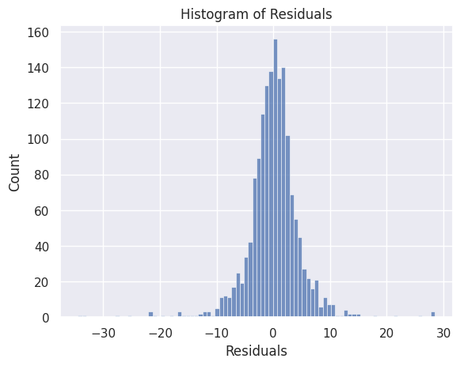

```python
residuals = y_test - predictions

sns.histplot(residuals).set(
    xlabel="Residuals",
    title="Histogram of Residuals")
```

I would say that this model answers the question and shows us that we are able to predict the passer rating of a quarterback.